# TutoRial - Part 1

Marine Ecosystem Dynamics

Authors

Kinlan Jan

Baptiste Serandour

## New script

As seen during the presentation, we will keep track of our progress. We thus need to open a new script following one of the option below.

```
flowchart LR
  A[1. File] --> B[2. New File]
  B --> C[3. R script]
```

```
flowchart LR
  A["⌘/Ctlr + ⇧ + N"]
```

## **R** syntax

**R** is a programming language that use a simplified syntax. In this section, you will explore how to write a script and execute it.

But first some syntax information:

- Everything after `#` is considered as a command and will not be executed. It is very important to write what we are doing, so we do not get lost next time we open our scripts.

```r
# 2 + 2 will not work because of the #
2 + 2 # We should then annotate our script like this
```

```
#> [1] 4
```

```r
2 + 2
```

```
#> [1] 4
```

```r
3 * 2
```

```
#> [1] 6
```

```r
# This can also be written as follow:
2 + 2 ; 3 * 2
```

```
#> [1] 4
#> [1] 6
```

- In **R** we can name a function, vector, or other object using `=`, `<-`, `->` or `assign`

```r
c(1, 2, 3, 4) -> my_first_vector
my_vector <- c(1, 2, 3, 4)
my_function = function(x){x + 2}
assign("x", c(2, 3, 4, 5))
```

- `==` is a logical function that can be translated as *is equal to*, contrarily *is not equal to* is written `!=`

```r
2 + 2 == 4
```

```
#> [1] TRUE
```

```r
3 * 2 == 4
```

```
#> [1] FALSE
```

```r
3 * 2 != 4
```

```
#> [1] TRUE
```

### Exercises

1. Do these calculations in a new **R** script
- $\ 2^7$

**Solution**

```r
2^7
```

```
#> [1] 128
```

- $\ cos(\pi)$

**Hint**

```r
?cos()
?pi()
```

**Solution**

```r
cos(pi)
```

```
#> [1] -1
```

- $\ \sum_{1}^{100} i$

**Hint**

Operations can take place for an entire vector

**Solution**

```r
vector <- seq(from = 1, to = 100, by = 1) # Create a vector from 1 to 100
sum(vector) # Calculate the sum
```

```
#> [1] 5050
```

2. Create a parameter `x1` that equals to 5 and a parameter `x2` that equals to 10

**Solution**

```r
x1 <- 5 ; x2 <-  10
```

3. Is 2`x1` equivalent to `x2`?

**Solution**

```r
2*x1 == x2
```

```
#> [1] TRUE
```

## Functions

As seen during the lecture, **R** works with functions that can:

- Already be implemented in base **R**
- Comming from another package
- Created by the user

We will see these three examples in this section, but first it is important to remember that the typical structure of a function is `function(argument_1, ...)`. It is impossible to remember what are all the argument, but fortunately **R** helps us:

- Using `help()` or `?`

```r
help(topic = "sin")
?sin
```

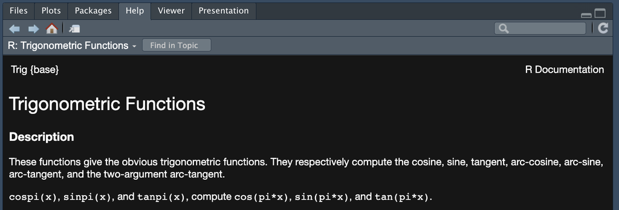

- Using `example`

```r
example(sum)
```

```
#>
#> sum> ## Pass a vector to sum, and it will add the elements together.
#> sum> sum(1:5)
#> [1] 15
#>
#> sum> ## Pass several numbers to sum, and it also adds the elements.
#> sum> sum(1, 2, 3, 4, 5)
#> [1] 15
#>
#> sum> ## In fact, you can pass vectors into several arguments, and everything gets added.
#> sum> sum(1:2, 3:5)
#> [1] 15
#>
#> sum> ## If there are missing values, the sum is unknown, i.e., also missing, ....
#> sum> sum(1:5, NA)
#> [1] NA
#>
#> sum> ## ... unless  we exclude missing values explicitly:
#> sum> sum(1:5, NA, na.rm = TRUE)
#> [1] 15
```

For the functions that comes from another package, we first need to install the new packages. The most common way to do so is by executing `install.packages("Package_Name")`. Then everytime you open a new session and you want to use the package, start the script by executing `library(Package_Name)`.

Finally, if you really do not find a suitable function in a package, or want to create your own function, you can create your functions following this general structure:

```r
my_function <- function(<argument_1>, <argument_2>, ...){
  <here comes the definition of my function>
  return(<output of the definition>)
}
```

### Exercises

- What is the function `log()` doing and from were does this function come from (base **R**, other packages)?

**Solution**

```r
?log() #It takes the natural logarithm of the value, it comes from base R
log(10)
```

- What are the mandatory arguments for the function `plot()`

**Solution**

```r
?plot() # the coordinates points x and y are needed
```

- Install the package named `readr` and load it

**Solution**

```r
install.packages("readr")
library(readr)
```

- Is there help associated with the functions from a loaded package?

**Hint**

The function `read_csv` comes from this package

**Solution**

```r
?read_csv # Yes, there is also help for the imported functions
```

**Optional exercises**

- Create a function that print `Hello World!` when executing it

**Solution**

```r
Hello <- function(){
  cat("Hello World!") # print("Hello World!") works too
}
Hello()
```

```
#> Hello World!
```

- Create a function that multiply the input by 4

**Solution**

```r
multiplyeR <- function(x, y = 4){
  return(x * y)
}
multiplyeR(x = 2) # It works with values
```

```
#> [1] 8
```

```r
multiplyeR(x = seq(1, 3, 1)) # But also vectors
```

```
#> [1]  4  8 12
```

## Vectors

**R** works with vector from which we can do our calculations. There is several way to create a vector:

- Using `c()` values are added next to each other

```r
c(1, 2, 1, 4) # It works with integers (round numbers)
```

```
#> [1] 1 2 1 4
```

```r
c(1.1, 2.4, pi) # It works with floats (decimal numbers)
```

```
#> [1] 1.100000 2.400000 3.141593
```

```r
c("chocolate", "ice-cream") # It works with character
```

```
#> [1] "chocolate" "ice-cream"
```

```r
c(TRUE, FALSE) # It works with logical variables
```

```
#> [1]  TRUE FALSE
```

- Using `rep()` to repeat the same values

```r
rep(3, 2) # It works with integers
```

```
#> [1] 3 3
```

```r
rep(3.2, 3) # It works with floats
```

```
#> [1] 3.2 3.2 3.2
```

```r
rep("chocolate", 2) # It works with character
```

```
#> [1] "chocolate" "chocolate"
```

```r
rep(TRUE, 3) # It works with logical variables
```

```
#> [1] TRUE TRUE TRUE
```

- For numeric values (integers and floats) we can also use `seq` that produce a sequence from a value to another one

```r
seq(from = 2, to = 6, by = 2)
```

```
#> [1] 2 4 6
```

```r
seq(from = 0, to = 1, by = 0.2)
```

```
#> [1] 0.0 0.2 0.4 0.6 0.8 1.0
```

**Tip**

if you want to do a sequence using `by = 1` it is easier to write it like this: `from:to`

```r
1:10
```

```
#>  [1]  1  2  3  4  5  6  7  8  9 10
```

```r
seq(from = 1, to = 10, by = 1) == 1:10
```

```
#>  [1] TRUE TRUE TRUE TRUE TRUE TRUE TRUE TRUE TRUE TRUE
```

- Finally, we can also combine vector together

```r
c(c(2, 1), seq(from = 2, to = 4, by = 0.5), rep("a", 2))
```

```
#> [1] "2"   "1"   "2"   "2.5" "3"   "3.5" "4"   "a"   "a"
```

### Exercises

- Create a vector `v1` that contains the values 3, 5, 1, 2, 6

**Solution**

```r
v1 <- c(3, 5, 1, 2, 6)
```

- Create a vector `v2` that contains four times the values 3, 5, 1, 2, 6

**Solution**

```r
v2 <- rep(v1, 4)
```

- Create a vector `v3` that repeats `TRUE`, `FALSE` 5 times

**Solution**

```r
v3 <- rep(c(TRUE, FALSE), 5)
```

- Create a vector `v4` that goes from 10 to 200

**Solution**

```r
v4 <- 10:200
```

- Create a vector `v5` that contains `v1`, `v2`, `v3` and 2 times `v4`

**Solution**

```r
v5 <- c(v1, v2, v3, rep(v4, 2))
```

## Tibbles

Now that we have seen how to create vectors, we can start combining them in a dataframe, called `tibble`.

- First, load (and install if it is not done `install.packages("tibble")`) the`tibble` package.

```r
library(tibble)
?tibble
```

- Second, fill a tibble

```r
tibble(Plankton_type = c(rep("Zooplankton", 6), rep("Phytoplankton", 6)),
       Biomass = c(65, 12, 42, 51, 23, 72, 10, 11, 21, 14, 23, 13))
```

```
#> # A tibble: 12 × 2
#>    Plankton_type Biomass
#>    <chr>           <dbl>
#>  1 Zooplankton        65
#>  2 Zooplankton        12
#>  3 Zooplankton        42
#>  4 Zooplankton        51
#>  5 Zooplankton        23
#>  6 Zooplankton        72
#>  7 Phytoplankton      10
#>  8 Phytoplankton      11
#>  9 Phytoplankton      21
#> 10 Phytoplankton      14
#> 11 Phytoplankton      23
#> 12 Phytoplankton      13
```

- Then, we can access the individual vector (or column of the tibble) using `$` or `[[]]`

```r
example <- tibble(Plankton_type = c(rep("Zooplankton", 6), rep("Phytoplankton", 6)),
       Biomass = c(65, 12, 42, 51, 23, 72, 10, 11, 21, 14, 23, 13))

example$Plankton_type
```

```
#>  [1] "Zooplankton"   "Zooplankton"   "Zooplankton"   "Zooplankton"
#>  [5] "Zooplankton"   "Zooplankton"   "Phytoplankton" "Phytoplankton"
#>  [9] "Phytoplankton" "Phytoplankton" "Phytoplankton" "Phytoplankton"
```

```r
example[[2]]
```

```
#>  [1] 65 12 42 51 23 72 10 11 21 14 23 13
```

### Exercises

- Create a tibble named `df` that look like this:

| Genus | Station | Abundance |
| --- | --- | --- |
| Acartia | B1 | 65.6 |
| Centropages | B1 | 32.6 |
| Centropages | B1 | 68.8 |
| Acartia | B1 | 91.0 |
| Temora | B1 | 53.4 |
| Temora | B1 | 89.6 |

**Solution**

```r
df <- tibble(Genus = c("Acartia", "Centropages", "Centropages", "Acartia", "Temora", "Temora"),
       Station = "B1",
       Abundance = c(65.6, 32.6, 68.8, 91.0, 53.4, 89.6))
```

- Create a vector `output` that correspond to the column `Abundance` of the tibble `df`

**Solution**

```r
output <- df$Abundance # or df[[3]]
```

## Importing data

Often, we are not preparing our dataset in **R**. Thus, importing dataset is essential to process our data. To do so, we will see how to use the `read_*` function from the `readr` package.

**Tip**

When saving our spreadsheet, it is always a good idea to save the document as *.csv*

A typical data import look like this

1. Set the working directory with its absolute path. So every time you want to import/export, you can use the relative path writen as `./...`

```r
setwd("/Absolute/Path/To/Working/Directory")
```

2. Load the `readr` package

```r
library(readr)
```

3. Import you dataset

```r
df <- read_csv("./The/relative/path/to/my/dataset.csv")
```

4. Examine the data if the importation worked well

```r
str(df)
```

### Exercises

- Import and inspect the dataset `zooplankton_seasonality.csv`

**Solution**

```r
plankton_seasonality <- read_csv("./../../assets/data/zooplankton_seasonality.csv")
str(plankton_seasonality)
```

or

```r
setwd("/Users/kinlan/OneDrive - Stockholm University/PhD/Teaching/MarineEcosystemDynamics2023/Tutorial")
plankton_seasonality <- read_csv("./Data/zooplankton_seasonality.csv")
str(plankton_seasonality)
```

```
#>
#> spc_tbl_ [2,956 × 7] (S3: spec_tbl_df/tbl_df/tbl/data.frame)
#>  $ Month_abb  : chr [1:2956] "Jan" "Jan" "Jan" "Jan" ...
#>  $ Year       : num [1:2956] 2009 2009 2009 2009 2009 ...
#>  $ Station    : chr [1:2956] "BY15" "BY31" "BY5" "BY15" ...
#>  $ Coordinates: chr [1:2956] "20.05000/57.33333" "18.23333/58.58812" "15.98333/55.25000" "20.05000/57.33333" ...
#>  $ Group      : chr [1:2956] "Copepoda" "Copepoda" "Copepoda" "Copepoda" ...
#>  $ Taxa       : chr [1:2956] "Acartia" "Acartia" "Acartia" "Centropages" ...
#>  $ Biomass    : num [1:2956] 6.65 1.82 5.56 5.74 1.23 ...
#>  - attr(*, "spec")=
#>   .. cols(
#>   ..   Month_abb = col_character(),
#>   ..   Year = col_double(),
#>   ..   Station = col_character(),
#>   ..   Coordinates = col_character(),
#>   ..   Group = col_character(),
#>   ..   Taxa = col_character(),
#>   ..   Biomass = col_double()
#>   .. )
#>  - attr(*, "problems")=<externalptr>
```

**Tip**

Sometimes it is tricky to import directly in the good format, so it might be better to specify that the new dataset is a `tibble`

```r
plankton_seasonality <- as_tibble(plankton_seasonality)
str(plankton_seasonality)
```

```
#> tibble [2,956 × 7] (S3: tbl_df/tbl/data.frame)
#>  $ Month_abb  : chr [1:2956] "Jan" "Jan" "Jan" "Jan" ...
#>  $ Year       : num [1:2956] 2009 2009 2009 2009 2009 ...
#>  $ Station    : chr [1:2956] "BY15" "BY31" "BY5" "BY15" ...
#>  $ Coordinates: chr [1:2956] "20.05000/57.33333" "18.23333/58.58812" "15.98333/55.25000" "20.05000/57.33333" ...
#>  $ Group      : chr [1:2956] "Copepoda" "Copepoda" "Copepoda" "Copepoda" ...
#>  $ Taxa       : chr [1:2956] "Acartia" "Acartia" "Acartia" "Centropages" ...
#>  $ Biomass    : num [1:2956] 6.65 1.82 5.56 5.74 1.23 ...
```

- How many rows and columns are there in this dataset?

**Solution**

```r
nrow(plankton_seasonality)
```

```
#> [1] 2956
```

```r
ncol(plankton_seasonality)
```

```
#> [1] 7
```

- Write the dataset `df` that you created in your working directory

**Solution**

```r
write_csv(df, file = "./Data/df.csv")
```

**Optional exercises**

- Import the dataset `phytoplankton_seasonality` available [here](https://github.com/KMGJan/MED/blob/main/assets/data/phytoplankton_seasonality.txt) using `readr`

**Hint**

This time it is a .txt file and not a .csv file

**Hint**

This file is separated by tabs. In **R** tabs are written as `\t`

**Solution**

```r
phytoplankton_df <- read_delim("./../../assets/data/phytoplankton_seasonality.txt", delim = "\t") |>
  as_tibble()
str(phytoplankton_df)
```

```
#> tibble [236 × 6] (S3: tbl_df/tbl/data.frame)
#>  $ Month_abb  : chr [1:236] "Jan" "Jan" "Jan" "Jan" ...
#>  $ Year       : num [1:236] 2012 2012 2012 2012 2012 ...
#>  $ Station    : chr [1:236] "BY15" "BY5" "BY15" "BY5" ...
#>  $ Coordinates: chr [1:236] "20.05000/57.33333" "15.98333/55.25000" "20.05000/57.33333" "15.98333/55.25000" ...
#>  $ Taxa       : chr [1:236] "Cyanobacteria" "Cyanobacteria" "Diatoms" "Diatoms" ...
#>  $ Biomass    : num [1:236] 0.0828 0.0603 0.1149 1.7211 1.1886 ...
```

- What is the 4th column of this dataset?

**Solution**

```r
phytoplankton_df[4]
```

```
#> # A tibble: 236 × 1
#>    Coordinates
#>    <chr>
#>  1 20.05000/57.33333
#>  2 15.98333/55.25000
#>  3 20.05000/57.33333
#>  4 15.98333/55.25000
#>  5 20.05000/57.33333
#>  6 15.98333/55.25000
#>  7 20.05000/57.33333
#>  8 15.98333/55.25000
#>  9 20.05000/57.33333
#> 10 15.98333/55.25000
#> # ℹ 226 more rows
```

- What are the values of this 4th column?

**Solution**

```r
phytoplankton_df[[4]] |>
  unique()
```

```
#> [1] "20.05000/57.33333" "15.98333/55.25000"
```

- How many observations are in this dataset?

**Solution**

```r
nrow(phytoplankton_df)
```

```
#> [1] 236
```

**Tip**

The decimal operator is not the same depending on the countries. For example in Sweden the default decimal operator is `,` but often the default decimal operator is `.`

It might therefore be important to change this setting when loading a dataset. This can be achieved using the `locale` function in the `read_*` function!

```r
read_delim(file = ...,
           delim = ";",
           locale = locale(decimal_mark = ","))
```